```python
import numpy as np
import pandas as pd
import matplotlib
import matplotlib.pyplot as plt
from pathlib import Path

from astropy.io import fits

import fcparams as fcm
matplotlib.rcParams = fcm.changeRCParams(
    matplotlib.rcParams,
    color="k",
    tickdir="in",
    mpl=matplotlib,
)
```

```python
%load_ext autoreload
%autoreload 2
```

# HERMES payloads performance

## Energy resolution at $0^oC$: low energy peaks

First, we load the calibrated datasets:

```python
PATH = Path().cwd().parent
DATA_PATH = PATH.joinpath("data")
T0_DATA_PATH = DATA_PATH.joinpath("T0thr105")

datafolder = {
    "pfm": T0_DATA_PATH.joinpath("220805_1534_hermes_pfm_55Fe109Cd137Cs_00deg_105thr_LV0d5"),
    "fm2": T0_DATA_PATH.joinpath("221220_1704_hermes_fm2_00deg_FeCdCs_thr105_finethr_LV0d5"),
    "fm3": T0_DATA_PATH.joinpath("230113_1506_hermes_fm3_55Fe109Cd137Cs_0deg_thr105_LV0d5"),
    "fm4": T0_DATA_PATH.joinpath("230320_1300_hermes_fm4_55Fe109Cd137Cs_0deg_thr105_LV0d5"),
    "fm5": T0_DATA_PATH.joinpath("230504_1422_hermes_fm5_55Fe109Cd137Cs_0deg_thr105_LV0d5"),
    "fm6": T0_DATA_PATH.joinpath("230518_1458_hermes_fm6_55Fe109Cd137Cs_0deg_thr105_LV0d5"),
}
```

We open the calibrated dataset for one FM.

```python
PAYLOAD = "fm6"
```

Put data in a table. Unluckily we have to mess with the endiands to get it right.

```python
from astropy.table import Table

def fits2dataframe(filepath):
    t = Table.read(filepath)
    d = np.array(t).byteswap().newbyteorder()
    df = t.to_pandas()
    df["EVTYPE"] = df["EVTYPE"].map({b"X": "X", b"S": "S"})
    df["QUADID"] = df["QUADID"].map({b"A": "A", b"B": "B", b"C": "C", b"D": "D"})
    return df

df = fits2dataframe(filepath = datafolder[PAYLOAD].joinpath("event_list.fits"))
df[:5]
```

|  | ENERGY | TIME | ELECTRONS | EVTYPE | CHN | QUADID |
| --- | --- | --- | --- | --- | --- | --- |
| 0 | 2.798648 | 0.141753 | 766.752930 | X | 15 | A |
| 1 | 26.520797 | 0.141753 | 766.752930 | X | 15 | A |
| 2 | 81.405700 | 0.142502 | 2218.342285 | S | 27 | B |
| 3 | 8.096949 | 0.142502 | 2218.342285 | S | 27 | B |
| 4 | 22.118471 | 0.143146 | 6059.854980 | X | 9 | B |

Histogram and plots the low-energy calibrated spectrum.

```python
bins = np.arange(2,30, 0.01) # keV
midpoints = (bins[1:] + bins[:-1]) / 2
xdf = df[df["EVTYPE"] == "X"]
counts, bins = np.histogram(xdf["ENERGY"], bins = bins)
```

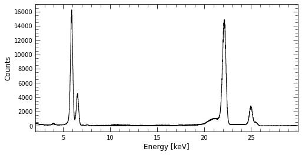

```python
%matplotlib inline
fig, ax = plt.subplots(figsize=(8, 4))
ax.step(midpoints, counts)
ax.set_xlim(bins[0], bins[-1])
ax.set_ylabel("Counts")
ax.set_xlabel("Energy [keV]")
plt.show()
```

We leverage on mescal's code to represent radioactive source. Note these structure contains the parameters `low_lim` and `hi_lim`. These parameters are expressed in unit of standard deviation and define the lower and upper limit for the source's fit interval.

```python
from radsources import radsources_dicts

xsources, _ = radsources_dicts(["55Fe", "109Cd", "137Cs"]); xsources
```

```
{'Fe 5.9 keV': Decay(energy=5.9, low_lim=-2.0, hi_lim=1.0),
 'Cd 22.1 keV': Decay(energy=22.16, low_lim=-1.0, hi_lim=2.0),
 'Cd 24.9 keV': Decay(energy=24.94, low_lim=-2.0, hi_lim=1.0)}
```

Again, we use mescal's calibration routines to fit the low-energy peaks.

```python
import fit

limits = [(s.energy - 0.2, s.energy + 0.2) for s in xsources.values()]
constraints = [(s.low_lim, s.hi_lim) for s in xsources.values()]

intervals, results = fit.gaussians_to_peaks(bins, counts, limits, constraints)

centers, center_errs, fwhms, fwhm_errs, amps, amp_errs = results
```

Plot the results:

```python
def normal(x, amp, sigma, x0):
    o = amp * np.exp(-((x - x0) ** 2) / (2 * sigma**2)) / (sigma * np.sqrt(2 * np.pi))
    return o
```

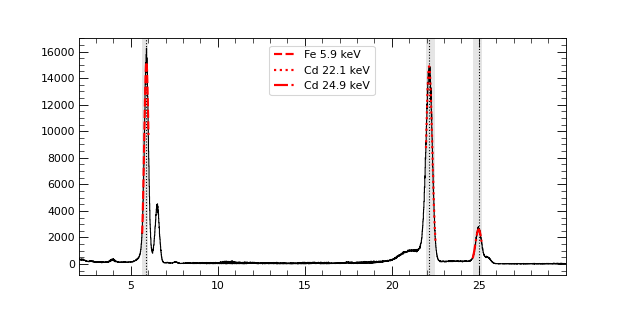

```python
%matplotlib notebook
fig, ax = plt.subplots(figsize = (8, 4))
ax.step(midpoints, counts, where="mid")
for ctr, amp, fwhm, interval, label in zip(centers, amps, fwhms, intervals, xsources.keys()):
    ax.axvline(ctr, linestyle="dotted")
    ax.axvspan(*interval, alpha=0.1)
    xs = np.linspace(*interval, 200)
    ax.plot(xs, normal(xs, amp, fwhm / 2.355, ctr), linewidth = 2, c='r', label=label)
ax.set_xlim(bins[0], bins[-1])
plt.legend()
plt.show()
```

```python
for source, fwhm in zip(xsources.keys(), fwhms):
    print(f"Resolution of {PAYLOAD} for source {source} is {fwhm:.3f} keV")
```

```
Resolution of fm6 for source Fe 5.9 keV is 0.293 keV
Resolution of fm6 for source Cd 22.1 keV is 0.414 keV
Resolution of fm6 for source Cd 24.9 keV is 0.425 keV
```

All that remains is to repeat this computation for all other flight models.

```python
bins = np.arange(2,30, 0.01) # keV
midpoints = (bins[1:] + bins[:-1]) / 2
xsources, _ = radsources_dicts(["55Fe", "109Cd", "137Cs"])
limits = [(s.energy - 0.2, s.energy + 0.2) for s in xsources.values()]
constraints = [(s.low_lim, s.hi_lim) for s in xsources.values()]

energy_res_dic = {}
for payload, dataset in datafolder.items():
    df = fits2dataframe(filepath = dataset.joinpath("event_list.fits"))
    xdf = df[df["EVTYPE"] == "X"]
    counts, bins = np.histogram(xdf["ENERGY"], bins = bins)
    intervals, results = fit.gaussians_to_peaks(bins, counts, limits, constraints)
    _, _, fwhms, fwhm_errs, _, _ = results
    energy_res_dic[payload] = np.dstack((fwhms, fwhm_errs)).reshape(-1)
```

And to report the results in a table:

```python
arrays = [
    [x for xy in list(zip(xsources.keys(), xsources.keys())) for x in xy],
    ["res [keV]", "err [keV]"]*len(xsources),
]
tuples = list(zip(*arrays))
index = pd.MultiIndex.from_tuples(tuples, names=["source", "value"])
pd.DataFrame(np.vstack([*energy_res_dic.values()]), index=energy_res_dic.keys(), columns=index)
```

| source value | Fe 5.9 keV res [keV] | Fe 5.9 keV err [keV] | Cd 22.1 keV res [keV] | Cd 22.1 keV err [keV] | Cd 24.9 keV res [keV] | Cd 24.9 keV err [keV] |
| --- | --- | --- | --- | --- | --- | --- |
| pfm | 0.374508 | 0.003427 | 0.477263 | 0.002778 | 0.514595 | 0.009344 |
| fm2 | 0.317333 | 0.004631 | 0.427502 | 0.002721 | 0.438174 | 0.006179 |
| fm3 | 0.299749 | 0.003011 | 0.420750 | 0.002416 | 0.441666 | 0.005435 |
| fm4 | 0.309350 | 0.004086 | 0.412766 | 0.002659 | 0.444314 | 0.005919 |
| fm5 | 0.294480 | 0.003382 | 0.415361 | 0.002659 | 0.442204 | 0.008065 |
| fm6 | 0.293480 | 0.002786 | 0.414423 | 0.002357 | 0.425140 | 0.005432 |

## Energy resolution at $0^oC$: high-energy resolution

We can use the same strategy to evaluate the payloads' resolution at $662$ keV.

For example, for FM6 we have:

```python
df = fits2dataframe(filepath = datafolder[PAYLOAD].joinpath("event_list.fits"))
```

```python
bins = np.arange(100, 800, 1.) # keV
midpoints = (bins[1:] + bins[:-1]) / 2
sdf = df[df["EVTYPE"] == "S"]
counts, bins = np.histogram(sdf["ENERGY"], bins = bins)
```

```python
_, gsources = radsources_dicts(["55Fe", "109Cd", "137Cs"])
limits = [(s.energy - 60, s.energy + 60) for s in gsources.values()]
constraints = [(s.low_lim, s.hi_lim) for s in gsources.values()]

intervals, results = fit.gaussians_to_peaks(bins, counts, limits, constraints)

centers, center_errs, fwhms, fwhm_errs, amps, amp_errs = results
```

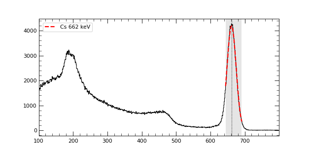

```python
%matplotlib notebook
fig, ax = plt.subplots(figsize = (8, 4))
ax.step(midpoints, counts, where="mid")
for ctr, amp, fwhm, interval, label in zip(centers, amps, fwhms, intervals, gsources.keys()):
    ax.axvline(ctr, linestyle="dotted")
    ax.axvspan(*interval, alpha=0.1)
    xs = np.linspace(*interval, 200)
    ax.plot(xs, normal(xs, amp, fwhm / 2.355, ctr), linewidth = 2, c='r', label=label)
ax.set_xlim(100, bins[-1])
plt.legend()
plt.show()
```

```python
for source, fwhm in zip(xsources.keys(), fwhms):
    print(f"Resolution of {PAYLOAD} for source {source} is {fwhm:.3f} keV")
```

```
Resolution of fm6 for source Fe 5.9 keV is 31.361 keV
```

Applying to other FMs:

```python
bins = np.arange(100, 800, 1.) # keV
midpoints = (bins[1:] + bins[:-1]) / 2
_, gsources = radsources_dicts(["55Fe", "109Cd", "137Cs"])
limits = [(s.energy - 60, s.energy + 60) for s in gsources.values()]
constraints = [(s.low_lim, s.hi_lim) for s in gsources.values()]

energy_res_dic = {}
for payload, dataset in datafolder.items():
    df = fits2dataframe(filepath = dataset.joinpath("event_list.fits"))
    sdf = df[df["EVTYPE"] == "S"]
    counts, bins = np.histogram(sdf["ENERGY"], bins = bins)
    intervals, results = fit.gaussians_to_peaks(bins, counts, limits, constraints)
    _, _, fwhms, fwhm_errs, _, _ = results
    energy_res_dic[payload] = np.dstack((fwhms, fwhm_errs)).reshape(-1)
```

```python
arrays = [
    [x for xy in list(zip(gsources.keys(), gsources.keys())) for x in xy],
    ["res [keV]", "err [keV]"]*len(xsources),
]
tuples = list(zip(*arrays))
index = pd.MultiIndex.from_tuples(tuples, names=["source", "value"])
pd.DataFrame(np.vstack([*energy_res_dic.values()]), index=energy_res_dic.keys(), columns=index)
```

| source value | Cs 662 keV res [keV] | Cs 662 keV err [keV] |
| --- | --- | --- |
| pfm | 31.722259 | 0.112399 |
| fm2 | 31.341184 | 0.126712 |
| fm3 | 31.375375 | 0.174114 |
| fm4 | 33.782737 | 0.285341 |
| fm5 | 31.886491 | 0.166801 |
| fm6 | 31.361304 | 0.164036 |

## Geometric area

We define the geometric area as: $$ A = ( N - 2n ) a $$

where $N = 120$ is the total number of detector channels, $n$ is the number of scintillators coupled to *two* off channels, and $a = 6.05\times7.44$ mm$^2$ is the area of an individual SDD cell.

The geometric area fraction is:

$$ F = \frac{A}{N a} = 1 - \frac{2 n}{N}$$

```python
N = 120
quad_scint_num = 120/4/2
a = 6.05 * 7.44 # mm2
```

Again, let's start with a single pl:

```python
PAYLOAD = "fm2"
```

We load the SDD calibration table:

```python
sdd_cal = pd.read_excel(datafolder[PAYLOAD].joinpath("report_cal.xlsx"), index_col=0, sheet_name=None)
sdd_cal["A"].head(5)
```

| channel | gain | gain_err | offset | offset_err | chi2 |
| --- | --- | --- | --- | --- | --- |
| 1.0 | 173.757047 | 0.817347 | 15206.796233 | 18.542111 | 57.962268 |
| 2.0 | 175.526457 | 0.105040 | 16335.817473 | 2.170541 | 7.027206 |
| 3.0 | 173.272813 | 1.042250 | 15314.137927 | 23.375007 | 235.681362 |
| 4.0 | 166.981513 | 1.265139 | 15975.907933 | 29.671417 | 54.346082 |
| 5.0 | 174.482043 | 0.209054 | 15734.067796 | 4.252581 | 21.751395 |

Now we get the detector maps:

```python
from detectors import Detector, supported_models

detectors = {d: Detector(d) for d in supported_models()}
print("loaded maps for ", supported_models())
```

```
loaded maps for  ['dm', 'pfm', 'fm1', 'fm2', 'fm3', 'fm4', 'fm5', 'fm6']
```

Once we have the detector maps we can query them about the `scint_id` of each channel. The `scint_id` is an integer identifier which gets assigned to all channels in a detectors. Two channels coupled to the same scintillator share the same `scint_id`. Once we got all the `scint_id` of calibrated channels we can count the unique ones to obtain $n$:

```python
quad = "A"
channels = sdd_cal[quad].index.values
scint_ids = [detectors[PAYLOAD].scintid(quad, ch) for ch in channels]
print(f"calibrated channels of {PAYLOAD}'s quadrant {quad} are :\n", channels)
print("for the same channels, the scintillator ids are :\n", scint_ids)
print("unique scintillator ids are :\n", set(scint_ids))
```

```
calibrated channels of fm2's quadrant A are :
 [ 1.  2.  3.  4.  5.  6.  8. 10. 11. 12. 13. 14. 16. 17. 18. 19. 20. 21.
 22. 23. 24. 27.]
for the same channels, the scintillator ids are :
 [6, 5, 14, 12, 5.0, 6.0, 20, 10.0, 17, 12.0, 19, 14.0, 18, 17.0, 18.0, 19.0, 20.0, 21.0, 31, 30, 29, 27.0]
unique scintillator ids are :
 {5, 6, 10.0, 12, 14, 17, 18, 19, 20, 21.0, 27.0, 29, 30, 31}
```

Putting things together:

```python
n_ = 0
for quad in "ABCD":
    channels = sdd_cal[quad].index.values
    unique_scint_ids = len(set([detectors[PAYLOAD].scintid(quad, ch) for ch in channels]))
    quadn_ = quad_scint_num - unique_scint_ids;
    print(f"for {payload} quadrant {quad}, n is {quadn_}")
    n_ += quadn_

print(f"total geometric area: {(N -  2*n_) * a / 100} cm2")
```

```
for fm6 quadrant A, n is 1.0
for fm6 quadrant B, n is 0.0
for fm6 quadrant C, n is 1.0
for fm6 quadrant D, n is 0.0
total geometric area: 52.21392 cm2
```

At this point we have everything to compute the geometric area:

```python
def geometric_area(payload):
    quad_scint_num = 120/4/2
    sdd_cal = pd.read_excel(datafolder[payload].joinpath("report_cal.xlsx"), index_col=0, sheet_name=None)

    n_ = 0
    for quad in "ABCD":
        channels = sdd_cal[quad].index.values
        unique_scint_ids = len(set([detectors[payload].scintid(quad, ch) for ch in channels]))
        quadn_ = quad_scint_num - unique_scint_ids;
        n_ += quadn_
    return (N - 2*n_) * a / 100
```

```python
geom_area = {}
for pl in filter(lambda p: p not in ["dm", "fm1"], supported_models()):
    geom_area[pl] = geometric_area(pl)

pd.DataFrame(geom_area, index=["geometric area [cm2]"]).round(decimals=1)
```

|  | pfm | fm2 | fm3 | fm4 | fm5 | fm6 |
| --- | --- | --- | --- | --- | --- | --- |
| geometric area [cm2] | 54.0 | 52.2 | 54.0 | 54.0 | 54.0 | 54.0 |

```python
(pd.DataFrame(geom_area, index=["geometric area fraction [%]"]) / (N * a /100) * 100).round(decimals=1)
```

|  | pfm | fm2 | fm3 | fm4 | fm5 | fm6 |
| --- | --- | --- | --- | --- | --- | --- |
| geometric area fraction [%] | 100.0 | 96.7 | 100.0 | 100.0 | 100.0 | 100.0 |

### Other approaches

Let's consider two alternative definitions of geometric area.

1. $A_x = (N - n') a$ where $n'$ is the number of off channels.
2. $A_s = n''a$ where $n''$ is the number of channels successfully s-calibrated.

```python
def geometric_area_x(payload):
    quad_sdd_num = 120/4
    n_ = 0
    sdd_cal = pd.read_excel(datafolder[payload].joinpath("report_cal.xlsx"), index_col=0, sheet_name=None)
    for quad in "ABCD":
        channels = sdd_cal[quad].index.values
        quadn_ = quad_sdd_num - len(channels);
        n_ += quadn_
    return (N - n_) * a / 100
```

```python
geom_area = {}
for pl in filter(lambda p: p not in ["dm", "fm1"], supported_models()):
    geom_area[pl] = geometric_area_x(pl)

pd.DataFrame(geom_area, index=["geometric area 'x' [cm2]"]).round(decimals=1)
```

|  | pfm | fm2 | fm3 | fm4 | fm5 | fm6 |
| --- | --- | --- | --- | --- | --- | --- |
| geometric area 'x' [cm2] | 49.5 | 45.0 | 48.6 | 48.6 | 48.6 | 50.4 |

```python
(pd.DataFrame(geom_area, index=["geometric area 'x' fraction [%]"]) / (N * a /100) * 100).round(decimals=1)
```

|  | pfm | fm2 | fm3 | fm4 | fm5 | fm6 |
| --- | --- | --- | --- | --- | --- | --- |
| geometric area 'x' fraction [%] | 91.7 | 83.3 | 90.0 | 90.0 | 90.0 | 93.3 |

```python
def geometric_area_s(payload):
    n_ = 0
    scint_cal = pd.read_excel(datafolder[payload].joinpath("report_slo.xlsx"), index_col=0, sheet_name=None)
    for quad in "ABCD":
        n_ += len(scint_cal[quad].index.values)
    return n_ * a / 100
```

```python
geom_area = {}
for pl in filter(lambda p: p not in ["dm", "fm1"], supported_models()):
    geom_area[pl] = geometric_area_s(pl)

pd.DataFrame(geom_area, index=["geometric area 's' [cm2]"]).round(decimals=1)
```

|  | pfm | fm2 | fm3 | fm4 | fm5 | fm6 |
| --- | --- | --- | --- | --- | --- | --- |
| geometric area 's' [cm2] | 45.0 | 37.8 | 43.2 | 43.2 | 43.2 | 45.0 |

```python
(pd.DataFrame(geom_area, index=["geometric area 's' fraction [%]"]) / (N * a /100) * 100).round(decimals=1)
```

|  | pfm | fm2 | fm3 | fm4 | fm5 | fm6 |
| --- | --- | --- | --- | --- | --- | --- |
| geometric area 's' fraction [%] | 83.3 | 70.0 | 80.0 | 80.0 | 80.0 | 83.3 |